# Elsa-analysis1

2023-09-27

# 1. Data pre-processing

## 1.1 General statistics

**Number of samples in total**

```
58
```

**Number of MAGs** The number of metagenome-assembled genomes (MAG) or draft bacterial genomes reconstructed from the metagenomic data.

```
472
```

**Amount of total data (GB):** The amount of total DNA data sequenced in gigabases (GB, one billion nucleotide bases).

```
333.71
```

**Amount of discarded data (GB):** The amount of data discarded due to low quality or lack of informativeness during data preprocesing. Discarding 5-15% of the produced data is within the expected range, due to formation of adaptor dimers, inclusion of adaptors in sequencing reads due to short insert sizes, low sequencing quality, etc.

```
10.37
```

**Amount of discarded data (in % of the raw data):**

```
3.11
```

**Amount of host data (GB):** The amount of data mapped against the host genome. The percentage refers to the amount of data mapped to the host genome respect to quality-filtered data. Note that this value can be very variable depending on the biological features of the sample (e.g., anal swabs contain more host DNA than faeces) and the employed reference genome (e.g., the chances for mapping to the genome are lower as the distance between) the study species and the employed reference genome differ).

```
6.49
```

**Amount of host data (% of the quality-filtered data):**

```
2.01
```

**Estimated prokaryotic data:** The amount and proportion of data belonging to prokayotic genomes respect to the total metagenomic fraction, as estimated from singleM analysis. Note that this is an estimation that relies on the genome sizes of genomes available in reference databases. If a given taxon is not properly represented, genome size estimations can be less accurate.

```
293.14
```

**Estimated prokaryotic data (% of the metagenomic data):**

```
92.51
```

```
316.85
```

**Amount of metagenomic data (% of the quality-filtered data):**

```
97.99
```

```
1833.71
```

**Total mapped sequencing depth (GB):**

```
262.22
```

```
31.62
```

**Average mapped sequencing depth (GB):**

```
4.52
```

## 1.2 MAG catalogue

### 1.2.1 Phylogenetic tree

The phylogenetic tree is constructed by placing the MAG sequences within the reference archaeal and bacterial trees using GTDBTK, followed by merging both trees.

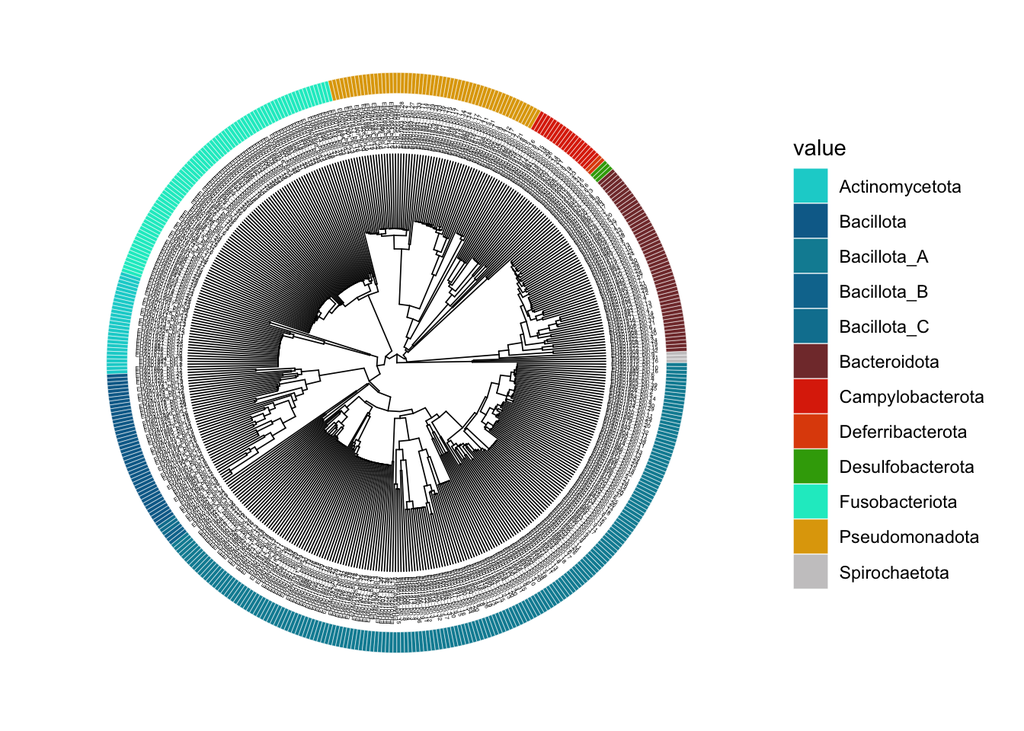

### 1.2.2 MAG details

Overview of the taxonomy and genome characteristics of the MAGs.  
**Completeness:** completeness of the MAG according to CheckM assessment.  
**Contamination:** contamination or redundancy of the MAG according to CheckM assessment.  
**Size:** size of the MAG in megabases (MB, one million nucleotide bases).

| Phylum | Completeness Mean | Completeness SD | Contamination Mean | Contamination SD | Size Mean | Size SD |
| --- | --- | --- | --- | --- | --- | --- |
| Actinomycetota | 72.68 | 14.68 | 3.70 | 2.43 | 1.33 | 0.33 |
| Bacillota | 85.99 | 16.12 | 2.20 | 2.49 | 1.85 | 0.52 |
| Bacillota_A | 74.55 | 17.28 | 3.19 | 3.09 | 1.88 | 0.65 |
| Bacillota_B | 68.95 | 26.89 | 0.98 | 1.33 | 1.50 | 0.35 |
| Bacillota_C | 92.12 | 13.57 | 0.12 | 0.10 | 1.84 | 0.18 |
| Bacteroidota | 81.74 | 18.83 | 2.34 | 3.02 | 2.64 | 0.71 |
| Campylobacterota | 86.50 | 18.52 | 0.76 | 1.47 | 1.66 | 0.35 |
| Deferribacterota | 96.30 | 0.54 | 0.56 | 0.15 | 2.18 | 0.13 |
| Desulfobacterota | 89.11 | 11.37 | 1.06 | 1.26 | 1.99 | 0.31 |
| Fusobacteriota | 68.15 | 14.44 | 4.22 | 2.78 | 1.43 | 0.54 |
| Pseudomonadota | 75.42 | 18.03 | 2.82 | 3.01 | 2.53 | 1.12 |
| Spirochaetota | 83.93 | 27.53 | 1.37 | 0.87 | 2.43 | 0.68 |

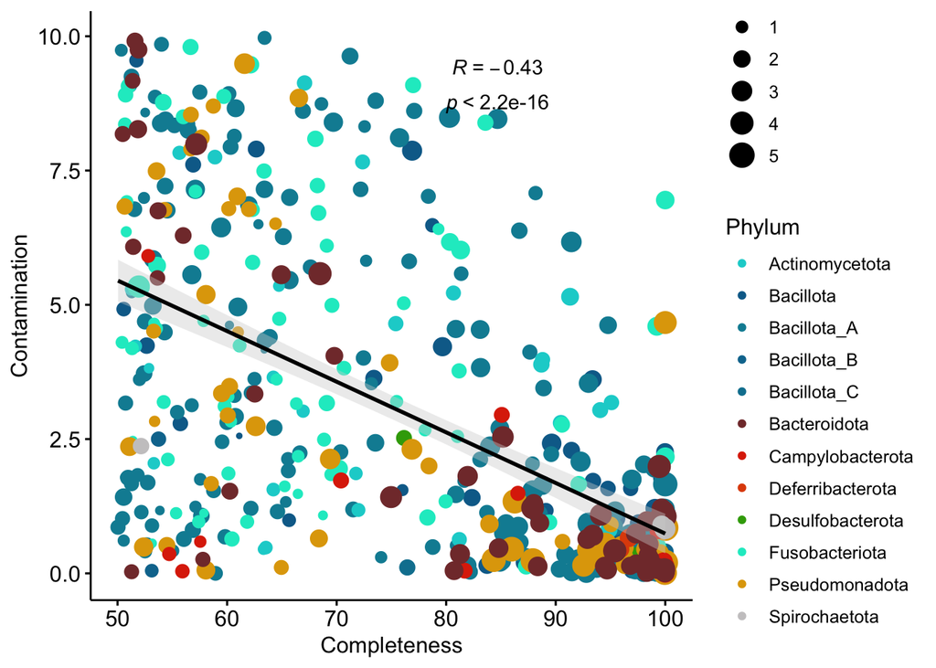

ELSA NOTE: this table appears to be clustered differently than the one in the DMB0024 file you sent me (see cluster here in Q4, rather than cluster in Q2 on the PDF). Though if I remember correctly, this figure matches the one you showed me in our meeting Monday morning.

## 1.3 Sequencing depth assessment

When performing genome-resolved metagenomic analyses on host-associated microbial communities, the data usually contains a mixture of origins. One fraction is low-quality data that is discarded in the bioinformatic preprocessing due to lack of informativeness. These data include low-quality bases, adaptors, low-complexity reads and alike, which do not contribute to the study. Another fraction belongs to the host genome against which the data are mapped. The host fraction can be very variable depending on the species and the sample type, and while it is not informative for metagenomic analyses, it can be used for genomic analyses. The rest is what we call the metagenomic fraction. Part of the metagenomic fraction is built into draft bacterial genomes or MAGs, against which metagenomic reads are mapped later on to quantify relative representation of genomes. The fraction that is not built into MAGs is what is also unmapped against the MAG catalogue. This last fraction includes DNA dietary items, viruses and other organisms, but can values_to include prokaryotic DNA of bacteria and archaea that were unable to be reconstructed.

In order to have representative results, the number of reads mapped to the MAG catalogue should be similar across samples. However, multiple reasons can create large imbalances, including uneven sequencing depth, different microbiome complexity across samples, different amount of host or non-microbial reads in the dataset, etc. The following plot shows the distribution of reads across samples.

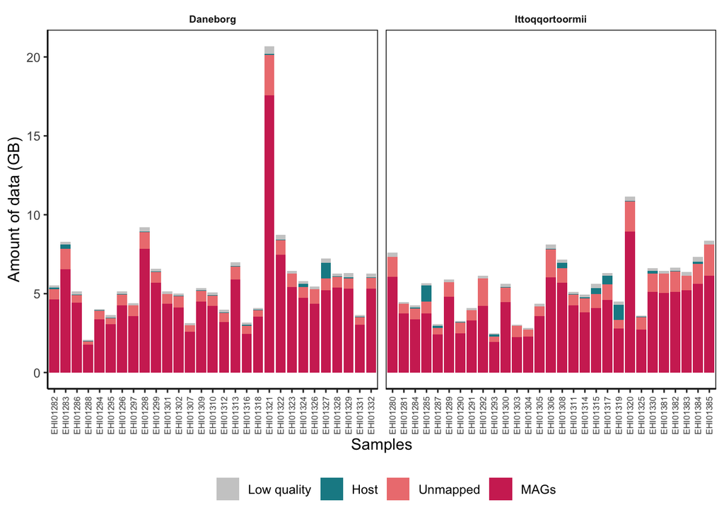

## 1.4 Minimum genome-coverage filtering

Mapping of sequencing reads against the reference genome catalogue is not perfect, and in consequence, all MAGs tend to get a few reads assigned. Implementing a minimum genome coverage filter aims at minimising artificial inflation of diversity due to this artifact of genome-resolved metagenomic analysis. However, if the sequencing depth is low and uneven across samples, this filtering can also introduce more distorsion.

## 1.5 Genome-size normalisation

Bacterial genomes can vary between 1 and 8 MB, which make relative representation of each genome dependent on its size. To account for genome size biases, read-counts can be normalised by applying a normalisation factor that modifies the read numbers according to the size of each genome compared to the average genome size in the dataset.

## 1.6 Count table

Once low-coverage genome counts have been filtered out, and the read counts have been normalised into genome counts, we can visualise the relative MAG abundances per sample. Note that the count scale is log-transformed.

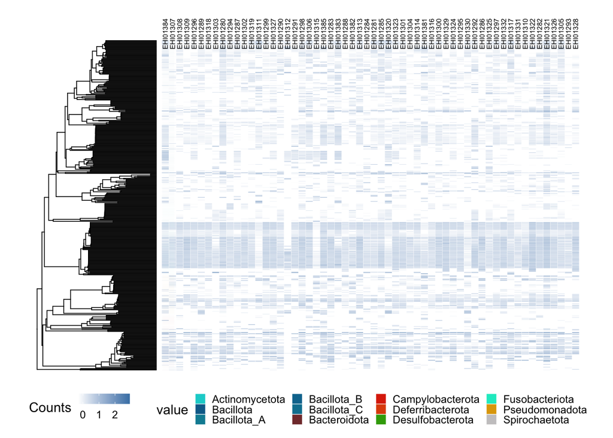

This appears to match the figure in the PDF report, though I am working now to correct the legand.

# 2. Taxonomic composition

Note that TSS normalisation simply divides each count value for the total count for the sample, thus transforming the data to 0-1 scale.

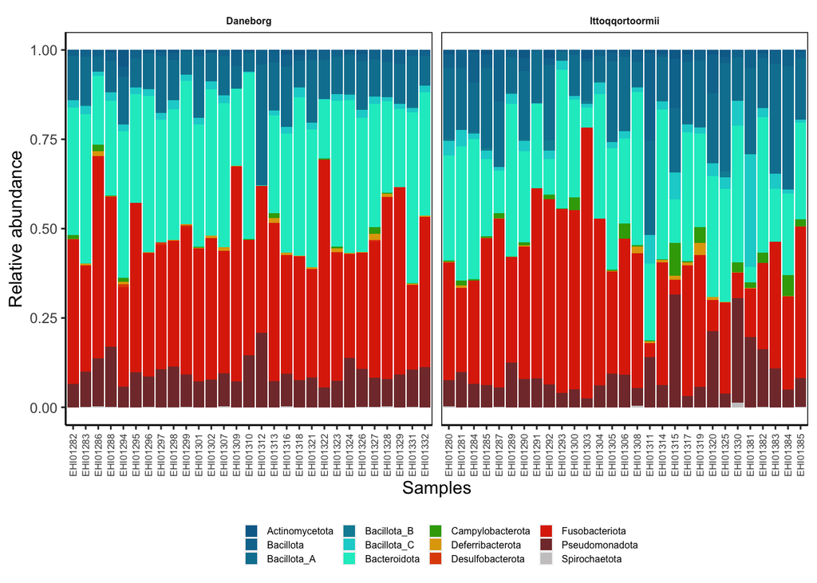

### Phylum percentages

```
           Phylum        Mean         SD
   Fusobacteriota 36.52981705 13.6670883
     Bacteroidota 30.61630730 11.2830067
      Bacillota_A 14.72431209  7.0953693
   Pseudomonadota  9.84239862  5.6334253
        Bacillota  3.25205484  3.9999827
      Bacillota_C  2.72076729  4.1657943
 Campylobacterota  0.92523782  1.6933868
   Actinomycetota  0.68998551  0.8725666
 Deferribacterota  0.40796874  0.5991154
      Bacillota_B  0.16963470  0.4383326
    Spirochaetota  0.07082906  0.1972588
 Desulfobacterota  0.05068698  0.1515987
```

# 3. Alpha diversity calculations

Diversity estimations for each sample.  
**Richness:** Number of MAGs per sample (after applying coverage filter).  
**Neutral diversity:** Hill number of q=1 (Shannon diversity), a diversity metric that accounts for richness and eveness (relative abundances) of the MAGs.  
**Phylogenetic diversity:** Phylogenetic Hill number of q=1, a diversity metric that accounts for richness and eveness (relative abundances), as well as phylogenetic relationships among MAGs.  
**Functional diversity:** Functional Hill number of q=1, a diversity metric that accounts for richness and eveness (relative abundances), as well as functional dissimilarities among MAGs.

### Neutral

#### Average neutral alpha diversities (q1)

| Groups | Mean | SD |
| --- | --- | --- |
| Daneborg | 98.525 | 19.991 |
| Ittoqqortoormii | 92.730 | 35.479 |

#### Correlations

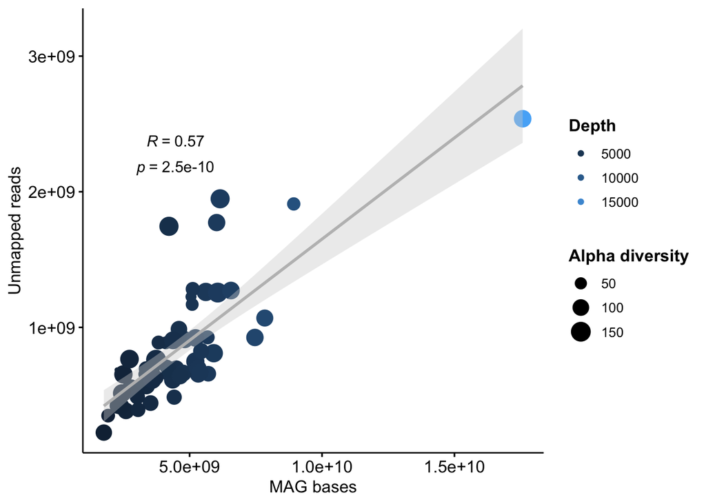

#### Alpha diversity plots

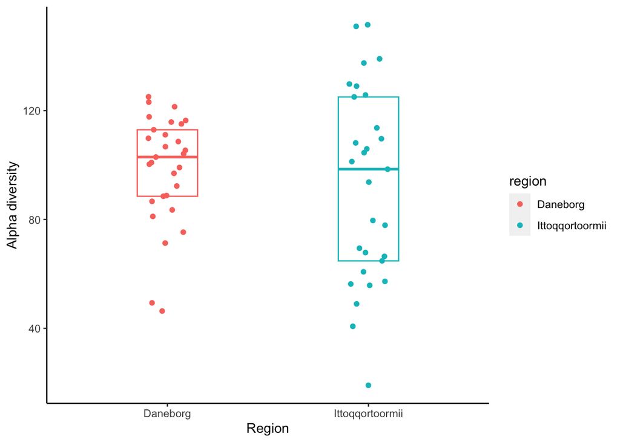

### Phylogenetic

#### Average phylogenetic alpha diversities

| Groups | Mean | SD |
| --- | --- | --- |
| Daneborg | 47.937 | 6.340 |
| Ittoqqortoormii | 50.490 | 12.749 |

#### Alpha diversity plots

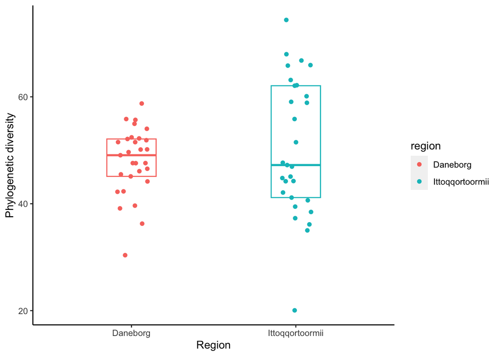

## Beta diversity calculations

### Neutral

```r
beta_div_neutral <- count_filtered %>%
#    select(-1) %>%
    t() %>% #transpose
    hill_taxa_parti_pairwise(., q = 1, pairs = "full") #calculate neutral beta diversities
```

#### NMDS:

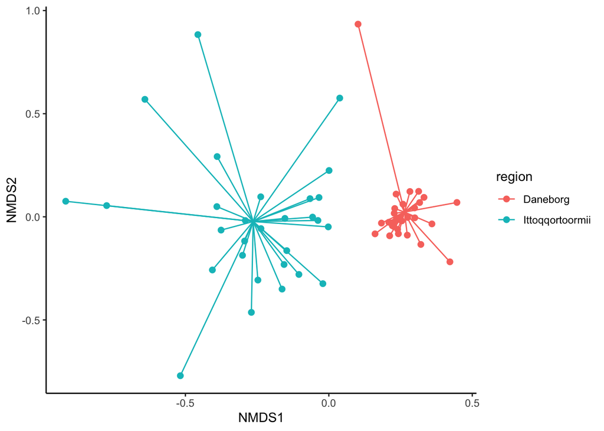

Adonis

```r
ps.disper.neutral <- betadisper(beta_div_neutral_dist, metadata$region)
permutest(ps.disper.neutral, pairwise = TRUE)
```

```
Permutation test for homogeneity of multivariate dispersions
Permutation: free
Number of permutations: 999

Response: Distances
          Df  Sum Sq   Mean Sq      F N.Perm Pr(>F)
Groups     1 0.00704 0.0070413 0.3706    999  0.537
Residuals 56 1.06391 0.0189984

Pairwise comparisons:
(Observed p-value below diagonal, permuted p-value above diagonal)
                Daneborg Ittoqqortoormii
Daneborg                           0.534
Ittoqqortoormii  0.54513
```

```r
# a p value of >0.05 in this case will tell you that the data is in an ok format for running an adonis
## results: P = 0.537

meta_order <- metadata[order(metadata$sample),]
m1 <- as.matrix(beta_div_neutral_dist)
metadata_ord<- metadata[order(match(metadata$sample,rownames(m1))),]
# this section correctly orders the metadata so that it matches to the beta diversity distance matrix

# Run test
adonis2(beta_div_neutral_dist ~ region, data =metadata_ord, permutations = 999)
```

```
Permutation test for adonis under reduced model
Terms added sequentially (first to last)
Permutation: free
Number of permutations: 999

adonis2(formula = beta_div_neutral_dist ~ region, data = metadata_ord, permutations = 999)
         Df SumOfSqs      R2      F Pr(>F)
region    1    6.535 0.12257 7.8224  0.001 ***
Residual 56   46.781 0.87743
Total    57   53.315 1.00000
---
Signif. codes:  0 '***' 0.001 '**' 0.01 '*' 0.05 '.' 0.1 ' ' 1
```

```r
# this is essentially a MANOVA. a p value of <0.05 is significant. The R2 value will tell you what amount of variation is based off the clustering variable. in this case the region.

## results: P = 0.001. R2 = 0.12257

## thus, the results ARE statistically significant, and 12% of variation is based on the region
```

Looking at the 6 different sled teams in Daneborg:

```r
# Filter the data for Daneborg
filtered_data <- all_metadata %>%
  filter(region == "Daneborg")

# NMDS analysis for Packs in Daneborg
beta_div_neutral_nmds_pack <- beta_div_neutral_dist %>%
  metaMDS(., trymax = 200, k = 2, verbosity = FALSE) %>%
  vegan::scores() %>%
  as_tibble(., rownames = "sample") %>%
  inner_join(., filtered_data, by = "sample")
```

```
*** Best solution repeated 1 times
```

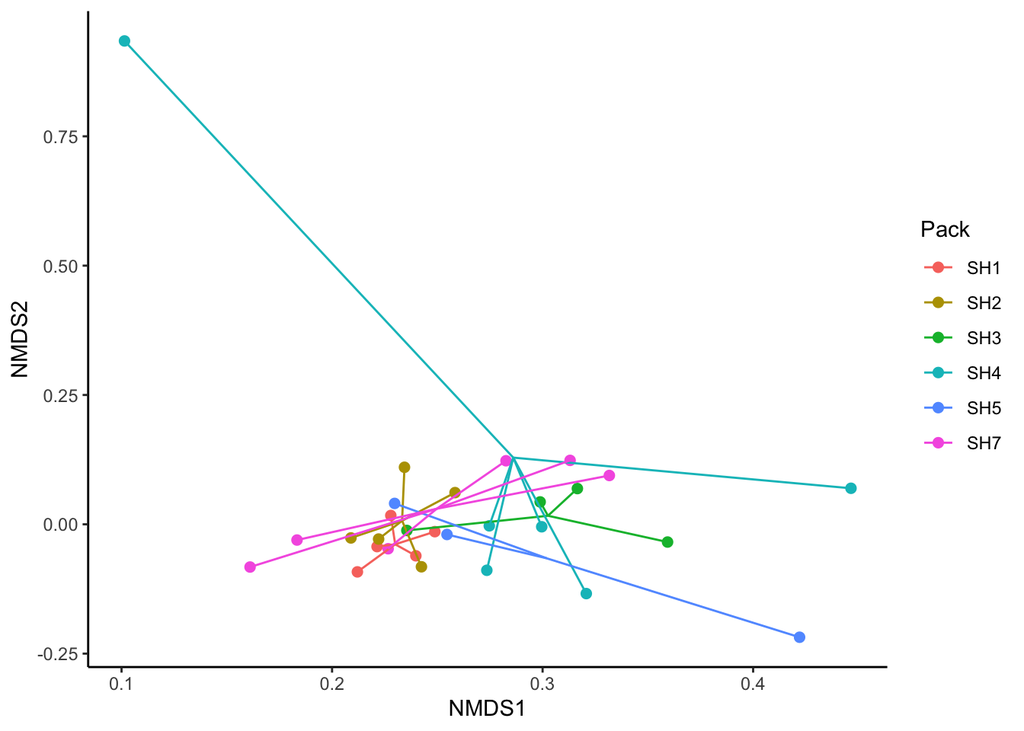

```r
# Create centroids
NMDS.centroids_2 <- aggregate(beta_div_neutral_nmds_pack[, c(2:3)], by = list(Pack = beta_div_neutral_nmds_pack$Pack), FUN = mean)
colnames(NMDS.centroids_2) <- c("Pack", "NMDS1", "NMDS2")
beta_div_neutral_nmds_pack <- merge(beta_div_neutral_nmds_pack, NMDS.centroids_2, by = "Pack")

# Plot the centroids and the samples
centroids <- beta_div_neutral_nmds_pack %>%
  group_by(Pack) %>%
  summarize(NM1 = mean(NMDS1.y), NM2 = mean(NMDS2.y))

ggplot(beta_div_neutral_nmds_pack, aes(x = NMDS1.x, y = NMDS2.x, colour = Pack)) +
  geom_point(aes(x = NMDS1.x, y = NMDS2.x), size = 2) +
  geom_segment(aes(x = NMDS1.y, y = NMDS2.y, xend = NMDS1.x, yend = NMDS2.x)) +
  theme(axis.line = element_line(colour = "grey"),
        panel.grid.major = element_blank(),
        panel.grid.minor = element_blank(),
        panel.border = element_blank(),
        panel.background = element_blank(),
        axis.title = element_blank(),
        legend.text = element_text(size = 14)) +
  theme_classic() +
  labs(x = "NMDS1", y = "NMDS2")
```

```r
ps.disper.neutral <- betadisper(beta_div_neutral_dist, all_metadata$Pack)
permutest(ps.disper.neutral, pairwise = TRUE)
```

```
Permutation test for homogeneity of multivariate dispersions
Permutation: free
Number of permutations: 999

Response: Distances
          Df  Sum Sq  Mean Sq     F N.Perm Pr(>F)
Groups    15 2.83229 0.188819 8.585    999  0.001 ***
Residuals 42 0.92375 0.021994
---
Signif. codes:  0 '***' 0.001 '**' 0.01 '*' 0.05 '.' 0.1 ' ' 1

Pairwise comparisons:
(Observed p-value below diagonal, permuted p-value above diagonal)
           P0        P1 P2        P3        P4        P5 P6 P7        P8 P9
P0            0.1110000    0.0680000 0.1130000 0.0930000       0.0080000
P1  0.1384536              0.8690000 0.7120000 0.6150000       0.9140000
P2
P3  0.1089171 0.8237603              0.6620000 0.5760000       0.8600000
P4  0.1348299 0.6624974    0.5794543           0.9110000       0.6600000
P5  0.1243752 0.5708602    0.5136006 0.8955725                 0.5510000
P6
P7
P8  0.0136220 0.9038072    0.8057988 0.5743751 0.4922490
P9
SH1 0.0686382 0.7214282    0.9302591 0.4389438 0.3679649       0.7001022
SH2 0.1519575 0.5577818    0.5236784 0.8537790 0.9513712       0.4996632
SH3 0.0617091 0.9638794    0.8050155 0.6324313 0.5468872       0.9145559
SH4 0.0515903 0.6119617    0.4752114 0.9669822 0.8407881       0.4685529
SH5 0.0591838 0.6720846    0.4740177 0.9698090 0.8719058       0.4057987
SH7 0.0092946 0.3525177    0.2081610 0.8019796 0.9483318       0.1567590
          SH1       SH2       SH3       SH4       SH5   SH7
P0  0.0380000 0.1290000 0.0400000 0.0310000 0.0280000 0.003
P1  0.7820000 0.6480000 0.9790000 0.6770000 0.7240000 0.397
P2
P3  0.9560000 0.5460000 0.8400000 0.4980000 0.5700000 0.206
P4  0.4990000 0.8760000 0.6990000 0.9810000 0.9770000 0.851
P5  0.4220000 0.9640000 0.6030000 0.8750000 0.8830000 0.962
P6
P7
P8  0.7610000 0.5530000 0.9300000 0.5040000 0.4370000 0.121
P9
SH1           0.4440000 0.7670000 0.3680000 0.3550000 0.080
SH2 0.3787495           0.6230000 0.8520000 0.8850000 0.988
SH3 0.6969075 0.5457582           0.6220000 0.6390000 0.286
SH4 0.3303363 0.7954138 0.5528341           0.9980000 0.735
SH5 0.3409471 0.8409428 0.5610297 0.9942500           0.756
SH7 0.1077447 0.9816616 0.2538386 0.6986355 0.7111398
```

```r
# a p value of >0.05 in this case will tell you that the data is in an ok format for running an adonis
## results: P = 0.001, therefore NOT appropriate for adonis
################### ALL BELOW NOT RELEVENT #############################


# meta_order_2 <- all_metadata[order(all_metadata$sample),]
# m2 <- as.matrix(beta_div_neutral_dist)
# metadata_ord_2<- all_metadata[order(match(all_metadata$sample,rownames(m2))),]
# this section correctly orders the metadata so that it matches to the beta diversity distance matrix

# Run test
# adonis2(beta_div_neutral_dist ~ Pack, data =metadata_ord_2, permutations = 999)
# this is essentially a MANOVA. a p value of <0.05 is significant. The R2 value will tell you what amount of variation is based off the clustering variable. in this case the packs.
```

Now Analysis for presence / absence of parasites:

```r
#### NMDS
beta_div_neutral_nmds_PR <- beta_div_neutral_dist %>%
  metaMDS(.,trymax = 200, k=2, verbosity=FALSE) %>%
  vegan::scores() %>%
  as_tibble(., rownames = "sample") %>%
  inner_join(., all_metadata, by="sample")
```

```
*** Best solution repeated 1 times
```

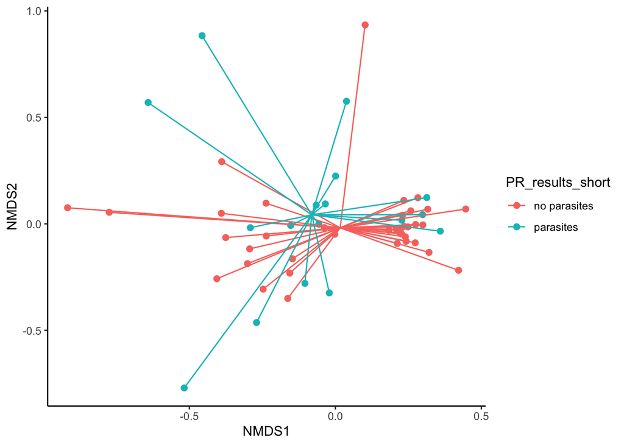

```r
beta_div_neutral_nmds_PR <- beta_div_neutral_nmds_PR %>%
  filter(PR_results_short != "excluded")

#### Create centroids
NMDS.centroids_3=aggregate(beta_div_neutral_nmds_PR[,c(2:3)],by=list(beta_div_neutral_nmds_PR$PR_results_short),FUN=mean)
colnames(NMDS.centroids_3) <- c("PR_results_short","NMDS1","NMDS2")
beta_div_neutral_nmds_PR=merge(beta_div_neutral_nmds_PR,NMDS.centroids_3,by="PR_results_short")

#### Plot the centroids and the samples.
centroids <- beta_div_neutral_nmds_PR  %>%
  group_by(PR_results_short)  %>%
  summarize(NM1=mean(NMDS1.y), NM2=mean(NMDS2.y))

ggplot(beta_div_neutral_nmds_PR, aes(x=NMDS1.x,y=NMDS2.x,colour=PR_results_short)) +
  geom_point(aes(x=NMDS1.x,y=NMDS2.x),size=2) +
  geom_segment(aes(x=NMDS1.y, y=NMDS2.y, xend=NMDS1.x, yend=NMDS2.x))+
  theme(axis.line = element_line(colour = "grey"),
        panel.grid.major = element_blank(),
        panel.grid.minor = element_blank(),
        panel.border = element_blank(),
        panel.background = element_blank(),
        axis.title=element_blank(),
        legend.text=element_text(size=14))+
  # facet_wrap(~ factor(type))+
  theme_classic()+
  labs( x = "NMDS1", y = "NMDS2")
```

```r
ps.disper.neutral <- betadisper(beta_div_neutral_dist, all_metadata$PR_results_short)
permutest(ps.disper.neutral, pairwise = TRUE)
```

```
Permutation test for homogeneity of multivariate dispersions
Permutation: free
Number of permutations: 999

Response: Distances
          Df  Sum Sq  Mean Sq     F N.Perm Pr(>F)
Groups     2 0.12544 0.062722 3.291    999  0.043 *
Residuals 55 1.04822 0.019058
---
Signif. codes:  0 '***' 0.001 '**' 0.01 '*' 0.05 '.' 0.1 ' ' 1

Pairwise comparisons:
(Observed p-value below diagonal, permuted p-value above diagonal)
             excluded no parasites parasites
excluded                  0.021000     0.019
no parasites 0.019703                  0.783
parasites    0.018257     0.794787
```

```r
# a p value of >0.05 in this case will tell you that the data is in an ok format for running an adonis
## results: P = 0.04, therefore NOT appropriate for adonis
################### ALL BELOW NOT RELEVENT #############################


# meta_order_3 <- all_metadata[order(all_metadata$sample),]
# m3 <- as.matrix(beta_div_neutral_dist)
# metadata_ord_3<- all_metadata[order(match(all_metadata$sample,rownames(m3))),]
# this section correctly orders the metadata so that it matches to the beta diversity distance matrix

# Run test
# adonis2(beta_div_neutral_dist_PR ~ PR_results_short, data =metadata_ord_3, permutations = 999)
# this is essentially a MANOVA. a p value of <0.05 is significant. The R2 value will tell you what amount of variation is based off the clustering variable. in this case the parasitic infection.
```

Now, just for fun, we look at the Ittoq dogs, by their packs:

```r
# Filter the data for Ittoqqortoormiit
filtered_data_2 <- all_metadata %>%
  filter(region == "Ittoqqortoormii")

# NMDS analysis for Packs in Daneborg
beta_div_neutral_nmds_ittoq <- beta_div_neutral_dist %>%
  metaMDS(., trymax = 200, k = 2, verbosity = FALSE) %>%
  vegan::scores() %>%
  as_tibble(., rownames = "sample") %>%
  inner_join(., filtered_data_2, by = "sample")
```

```
*** Best solution repeated 1 times
```

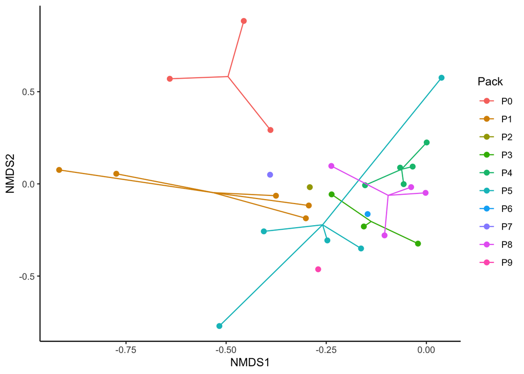

```r
# Create centroids
NMDS.centroids_4 <- aggregate(beta_div_neutral_nmds_ittoq[, c(2:3)], by = list(Pack = beta_div_neutral_nmds_ittoq$Pack), FUN = mean)
colnames(NMDS.centroids_4) <- c("Pack", "NMDS1", "NMDS2")
beta_div_neutral_nmds_ittoq <- merge(beta_div_neutral_nmds_ittoq, NMDS.centroids_4, by = "Pack")

# Plot the centroids and the samples
centroids <- beta_div_neutral_nmds_ittoq %>%
  group_by(Pack) %>%
  summarize(NM1 = mean(NMDS1.y), NM2 = mean(NMDS2.y))

ggplot(beta_div_neutral_nmds_ittoq, aes(x = NMDS1.x, y = NMDS2.x, colour = Pack)) +
  geom_point(aes(x = NMDS1.x, y = NMDS2.x), size = 2) +
  geom_segment(aes(x = NMDS1.y, y = NMDS2.y, xend = NMDS1.x, yend = NMDS2.x)) +
  theme(axis.line = element_line(colour = "grey"),
        panel.grid.major = element_blank(),
        panel.grid.minor = element_blank(),
        panel.border = element_blank(),
        panel.background = element_blank(),
        axis.title = element_blank(),
        legend.text = element_text(size = 14)) +
  theme_classic() +
  labs(x = "NMDS1", y = "NMDS2")
```

```r
ps.disper.neutral <- betadisper(beta_div_neutral_dist, all_metadata$Pack)
permutest(ps.disper.neutral, pairwise = TRUE)
```

```
Permutation test for homogeneity of multivariate dispersions
Permutation: free
Number of permutations: 999

Response: Distances
          Df  Sum Sq  Mean Sq     F N.Perm Pr(>F)
Groups    15 2.83229 0.188819 8.585    999  0.001 ***
Residuals 42 0.92375 0.021994
---
Signif. codes:  0 '***' 0.001 '**' 0.01 '*' 0.05 '.' 0.1 ' ' 1

Pairwise comparisons:
(Observed p-value below diagonal, permuted p-value above diagonal)
           P0        P1 P2        P3        P4        P5 P6 P7        P8 P9
P0            0.0990000    0.0690000 0.0990000 0.0940000       0.0120000
P1  0.1384536              0.8720000 0.7020000 0.6480000       0.9300000
P2
P3  0.1089171 0.8237603              0.6200000 0.5680000       0.8300000
P4  0.1348299 0.6624974    0.5794543           0.9230000       0.6630000
P5  0.1243752 0.5708602    0.5136006 0.8955725                 0.5140000
P6
P7
P8  0.0136220 0.9038072    0.8057988 0.5743751 0.4922490
P9
SH1 0.0686382 0.7214282    0.9302591 0.4389438 0.3679649       0.7001022
SH2 0.1519575 0.5577818    0.5236784 0.8537790 0.9513712       0.4996632
SH3 0.0617091 0.9638794    0.8050155 0.6324313 0.5468872       0.9145559
SH4 0.0515903 0.6119617    0.4752114 0.9669822 0.8407881       0.4685529
SH5 0.0591838 0.6720846    0.4740177 0.9698090 0.8719058       0.4057987
SH7 0.0092946 0.3525177    0.2081610 0.8019796 0.9483318       0.1567590
          SH1       SH2       SH3       SH4       SH5   SH7
P0  0.0450000 0.1200000 0.0390000 0.0380000 0.0390000 0.002
P1  0.7640000 0.6300000 0.9730000 0.6720000 0.7630000 0.395
P2
P3  0.9670000 0.5890000 0.8480000 0.5120000 0.5500000 0.191
P4  0.5140000 0.8980000 0.7100000 0.9690000 0.9730000 0.828
P5  0.4140000 0.9620000 0.5920000 0.8590000 0.9100000 0.962
P6
P7
P8  0.7750000 0.5560000 0.9410000 0.5180000 0.4860000 0.128
P9
SH1           0.4260000 0.7740000 0.3960000 0.3970000 0.093
SH2 0.3787495           0.5980000 0.8380000 0.8780000 0.993
SH3 0.6969075 0.5457582           0.6250000 0.6410000 0.258
SH4 0.3303363 0.7954138 0.5528341           0.9970000 0.746
SH5 0.3409471 0.8409428 0.5610297 0.9942500           0.761
SH7 0.1077447 0.9816616 0.2538386 0.6986355 0.7111398
```

```r
# a p value of >0.05 in this case will tell you that the data is in an ok format for running an adonis
## results: P = 0.001, therefore NOT appropriate for adonis
################### ALL BELOW NOT RELEVENT #############################


# meta_order_4 <- all_metadata[order(all_metadata$sample),]
# m4 <- as.matrix(beta_div_neutral_dist)
# metadata_ord_4<- all_metadata[order(match(all_metadata$sample,rownames(m4))),]
# this section correctly orders the metadata so that it matches to the beta diversity distance matrix

# Run test
# adonis2(beta_div_neutral_dist_ittoq ~ Pack, data =metadata_ord_4, permutations = 999)
# this is essentially a MANOVA. a p value of <0.05 is significant. The R2 value will tell you what amount of variation is based off the clustering variable. in this case the packs.
```